# Práctica General - Curso: Manejo y visualización de datos en R

María Gallego García

Enero 2022

## Ejercicio 1

##### (1A) Número de individuos totales, masculinos y femeninos por especie.

##### (1B) La media, desviación estándar, valor mínimo y máximo de la longitud y profundidad del pico, la longitud de la aleta y el tamaño.

###### Resultados

**(1A)**

Número de individuos totales M y F por especie

| species | sex | n |
| --- | --- | --- |
| Adelie | female | 73 |
| Adelie | male | 73 |
| Adelie | NA | 6 |
| Chinstrap | female | 34 |
| Chinstrap | male | 34 |
| Gentoo | female | 58 |
| Gentoo | male | 61 |
| Gentoo | NA | 5 |

**(1B)**

Medias, desviaciones y rangos (min y max) de logitud y profundidad pico, longitud aleta y tamaño

| species | media_longpico | sd_longpico | min_max_longpico | media_profpico | sd_profpico | min_max_profpico | media_longaleta | sd_longaleta | min_max_longaleta | media_tamaño | sd_tamaño | min_max_tamaño |
| --- | --- | --- | --- | --- | --- | --- | --- | --- | --- | --- | --- | --- |
| Adelie | 38.79139 | 2.663405 | 32.1 | 18.34636 | 1.2166498 | 15.5 | 189.9536 | 6.539457 | 172 | 3700.662 | 458.5661 | 2850 |
| Adelie | 38.79139 | 2.663405 | 46.0 | 18.34636 | 1.2166498 | 21.5 | 189.9536 | 6.539457 | 210 | 3700.662 | 458.5661 | 4775 |
| Chinstrap | 48.83382 | 3.339256 | 40.9 | 18.42059 | 1.1353951 | 16.4 | 195.8235 | 7.131894 | 178 | 3733.088 | 384.3351 | 2700 |
| Chinstrap | 48.83382 | 3.339256 | 58.0 | 18.42059 | 1.1353951 | 20.8 | 195.8235 | 7.131894 | 212 | 3733.088 | 384.3351 | 4800 |
| Gentoo | 47.50488 | 3.081857 | 40.9 | 14.98211 | 0.9812198 | 13.1 | 217.1870 | 6.484976 | 203 | 5076.016 | 504.1162 | 3950 |
| Gentoo | 47.50488 | 3.081857 | 59.6 | 14.98211 | 0.9812198 | 17.3 | 217.1870 | 6.484976 | 231 | 5076.016 | 504.1162 | 6300 |

## Ejercicio 2

##### (2A) Un gráfico de barras que represente el número de individuos muestreados de cada especie en cada isla, representando las especies en diferentes colores (chinstrap – morado, gentoo – azul, adelie – naranja).

##### (2B) Contesta a las siguientes preguntas: ¿qué especie se ha muestreado en las tres islas? ¿cuántos individuos se han muestreado de la isla Dream?

###### Gráfico y respuestas

**(2A)**

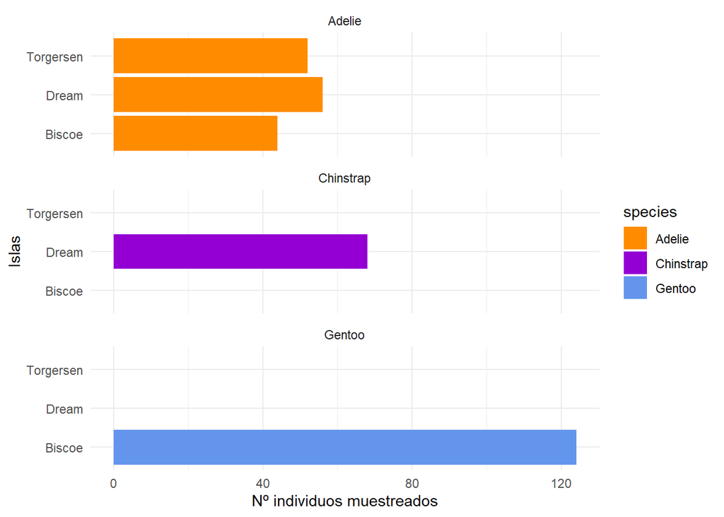

**(2B)**

¿Qué especie se ha muestreado en las tres islas?: **La especie Adelie** ¿Cuántos individuos se han muestreado de la isla Dream?:**124 individuos**

## Ejercicio 3

##### (3A) Un gráfico multipanel de cajas y bigotes del tamaño de los pingüinos según su sexo, donde aparezca un panel para cada especie.

##### (3B) Contesta a las siguientes preguntas: ¿qué especie tiene mayor tamaño? ¿en qué especie las hembras y los machos tienen un tamaño más similar?

###### Gráfico y respuestas

**(3A)**

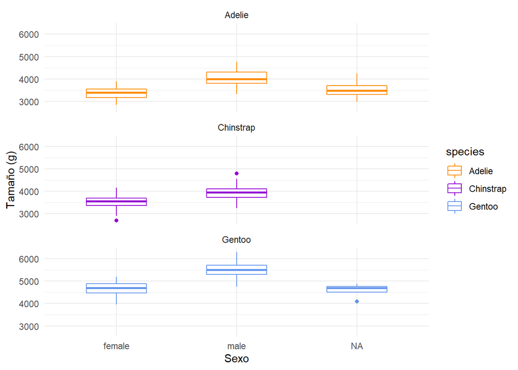

**(3B)**

¿Qué especie tiene mayor tamaño?: **La especie Gentoo** ¿En qué especie las hembras y los machos tienen un tamaño más similar?: **En la especie Chinstrap**